# Google Analytics Capstone Project: How Does a Bike-Share Navigate Speedy Success?

N Austin

2023-12-19

## How Does a Bike-Share Navigate Speedy Success?

### Google Analytics Capstone Project: Case stay 1. Cyclistic Bike-Share

### 1. Introduction: How do annual members and casual riders use Cyclistic bikes differently?

[figure not shown]

Bike rental

Image [W.Bulach](https://commons.wikimedia.org/wiki/User:W._Bulach)

### 2. Scenario

You are a junior data analyst working in the marketing analyst team at Cyclistic, a bike-share company in Chicago. The director of marketing believes the company’s future success depends on maximizing the number of annual memberships. Therefore, your team wants to understand how casual riders and annual members use Cyclistic bikes differently. From these insights, your team will design a new marketing strategy to convert casual riders into annual members. But first, Cyclistic executives must approve your recommendations, so they must be backed up with compelling data insights and professional data visualizations.

#### About the company

In 2016, Cyclistic launched a successful bike-share offering. Since then, the program has grown to a fleet of 5,824 bicycles that are geotracked and locked into a network of 692 stations across Chicago. The bikes can be unlocked from one station and returned to any other station in the system anytime.

#### Tasks

Produce a report with the following deliverables: * 1. A clear statement of the business task * 2. A description of all data sources used * 3. Documentation of any cleaning or manipulation of data * 4. A summary of your analysis * 5. Supporting visualizations and key findings * 6. Your top three recommendations based on your analysis

### 3. Business task: How do annual members and casual riders use Cyclistic bikes differently?

Analyse the data from the previous 12 months and find out how the different members use the bikes so we can target more casual members via a digital marketing strategy to become annual members.

##### Data: where has it come from and what time frame.

The data is a set of .csv files provided by the company for each month from December 22 to November 23

#### Preparation for analysis.

```r
library(tidyverse)
library(lubridate)
library(skimr)
library(dplyr)
library(tidyr)
library(DataExplorer)
library(scales)
library(forcats)
```

### 4. Importing and data validation.

Read in individual data sets.

```r
dec22 <- read_csv("./2023_bike_trips_working_directory/202212-divvy-tripdata.csv")
jan23 <- read_csv("./2023_bike_trips_working_directory/202301-divvy-tripdata.csv")
feb23 <- read_csv("./2023_bike_trips_working_directory/202302-divvy-tripdata.csv")
mar23 <- read_csv("./2023_bike_trips_working_directory/202303-divvy-tripdata.csv")
apr23 <- read_csv("./2023_bike_trips_working_directory/202304-divvy-tripdata.csv")
may23 <- read_csv("./2023_bike_trips_working_directory/202305-divvy-tripdata.csv")
jun23 <- read_csv("./2023_bike_trips_working_directory/202306-divvy-tripdata.csv")
jul23 <- read_csv("./2023_bike_trips_working_directory/202307-divvy-tripdata.csv")
aug23 <- read_csv("./2023_bike_trips_working_directory/202308-divvy-tripdata.csv")
sep23 <- read_csv("./2023_bike_trips_working_directory/202309-divvy-tripdata.csv")
oct23 <- read_csv("./2023_bike_trips_working_directory/202310-divvy-tripdata.csv")
nov23 <- read_csv("./2023_bike_trips_working_directory/202311-divvy-tripdata.csv")
```

Merge all data sets into 1 file.

```r
data <- rbind(dec22,jan23,feb23,mar23,apr23,may23,jun23,jul23,aug23,sep23,oct23,nov23)
```

```r
head(data)
```

```
## # A tibble: 6 × 13
##   ride_id          rideable_type started_at          ended_at
##   <chr>            <chr>         <dttm>              <dttm>
## 1 65DBD2F447EC51C2 electric_bike 2022-12-05 10:47:18 2022-12-05 10:56:34
## 2 0C201AA7EA0EA1AD classic_bike  2022-12-18 06:42:33 2022-12-18 07:08:44
## 3 E0B148CCB358A49D electric_bike 2022-12-13 08:47:45 2022-12-13 08:59:51
## 4 54C5775D2B7C9188 classic_bike  2022-12-13 18:50:47 2022-12-13 19:19:48
## 5 A4891F78776D35DF classic_bike  2022-12-14 16:13:39 2022-12-14 16:27:50
## 6 DB91D9B8DFACA07A electric_bike 2022-12-02 15:24:47 2022-12-02 15:34:14
## # ℹ 9 more variables: start_station_name <chr>, start_station_id <chr>,
## #   end_station_name <chr>, end_station_id <chr>, start_lat <dbl>,
## #   start_lng <dbl>, end_lat <dbl>, end_lng <dbl>, member_casual <chr>
```

### 5.Exploratory Data Analysis

Lets have a peak at our data.

```r
str(data)
```

```
## spc_tbl_ [5,677,610 × 13] (S3: spec_tbl_df/tbl_df/tbl/data.frame)
##  $ ride_id           : chr [1:5677610] "65DBD2F447EC51C2" "0C201AA7EA0EA1AD" "E0B148CCB358A49D" "54C5775D2B7C9188" ...
##  $ rideable_type     : chr [1:5677610] "electric_bike" "classic_bike" "electric_bike" "classic_bike" ...
##  $ started_at        : POSIXct[1:5677610], format: "2022-12-05 10:47:18" "2022-12-18 06:42:33" ...
##  $ ended_at          : POSIXct[1:5677610], format: "2022-12-05 10:56:34" "2022-12-18 07:08:44" ...
##  $ start_station_name: chr [1:5677610] "Clifton Ave & Armitage Ave" "Broadway & Belmont Ave" "Sangamon St & Lake St" "Shields Ave & 31st St" ...
##  $ start_station_id  : chr [1:5677610] "TA1307000163" "13277" "TA1306000015" "KA1503000038" ...
##  $ end_station_name  : chr [1:5677610] "Sedgwick St & Webster Ave" "Sedgwick St & Webster Ave" "St. Clair St & Erie St" "Damen Ave & Madison St" ...
##  $ end_station_id    : chr [1:5677610] "13191" "13191" "13016" "13134" ...
##  $ start_lat         : num [1:5677610] 41.9 41.9 41.9 41.8 41.9 ...
##  $ start_lng         : num [1:5677610] -87.7 -87.6 -87.7 -87.6 -87.7 ...
##  $ end_lat           : num [1:5677610] 41.9 41.9 41.9 41.9 41.9 ...
##  $ end_lng           : num [1:5677610] -87.6 -87.6 -87.6 -87.7 -87.7 ...
##  $ member_casual     : chr [1:5677610] "member" "casual" "member" "member" ...
##  - attr(*, "spec")=
##   .. cols(
##   ..   ride_id = col_character(),
##   ..   rideable_type = col_character(),
##   ..   started_at = col_datetime(format = ""),
##   ..   ended_at = col_datetime(format = ""),
##   ..   start_station_name = col_character(),
##   ..   start_station_id = col_character(),
##   ..   end_station_name = col_character(),
##   ..   end_station_id = col_character(),
##   ..   start_lat = col_double(),
##   ..   start_lng = col_double(),
##   ..   end_lat = col_double(),
##   ..   end_lng = col_double(),
##   ..   member_casual = col_character()
##   .. )
##  - attr(*, "problems")=<externalptr>
```

```r
glimpse(data)
```

```
## Rows: 5,677,610
## Columns: 13
## $ ride_id            <chr> "65DBD2F447EC51C2", "0C201AA7EA0EA1AD", "E0B148CCB3…
## $ rideable_type      <chr> "electric_bike", "classic_bike", "electric_bike", "…
## $ started_at         <dttm> 2022-12-05 10:47:18, 2022-12-18 06:42:33, 2022-12-…
## $ ended_at           <dttm> 2022-12-05 10:56:34, 2022-12-18 07:08:44, 2022-12-…
## $ start_station_name <chr> "Clifton Ave & Armitage Ave", "Broadway & Belmont A…
## $ start_station_id   <chr> "TA1307000163", "13277", "TA1306000015", "KA1503000…
## $ end_station_name   <chr> "Sedgwick St & Webster Ave", "Sedgwick St & Webster…
## $ end_station_id     <chr> "13191", "13191", "13016", "13134", "13288", "KA150…
## $ start_lat          <dbl> 41.91824, 41.94011, 41.88592, 41.83846, 41.89595, 4…
## $ start_lng          <dbl> -87.65711, -87.64545, -87.65113, -87.63541, -87.667…
## $ end_lat            <dbl> 41.92217, 41.92217, 41.89435, 41.88137, 41.92008, 4…
## $ end_lng            <dbl> -87.63889, -87.63889, -87.62280, -87.67493, -87.677…
## $ member_casual      <chr> "member", "casual", "member", "member", "casual", "…
```

```r
skim_without_charts(data)
```

Data summary

| Name | data |
| --- | --- |
| Number of rows | 5677610 |
| Number of columns | 13 |
| _______________________ |  |
| Column type frequency: |  |
| character | 7 |
| numeric | 4 |
| POSIXct | 2 |
| ________________________ |  |
| Group variables | None |

**Variable type: character**

| skim_variable | n_missing | complete_rate | min | max | empty | n_unique | whitespace |
| --- | --- | --- | --- | --- | --- | --- | --- |
| ride_id | 0 | 1.00 | 16 | 16 | 0 | 5677610 | 0 |
| rideable_type | 0 | 1.00 | 11 | 13 | 0 | 3 | 0 |
| start_station_name | 869289 | 0.85 | 3 | 64 | 0 | 1588 | 0 |
| start_station_id | 869421 | 0.85 | 3 | 35 | 0 | 1505 | 0 |
| end_station_name | 922436 | 0.84 | 3 | 64 | 0 | 1597 | 0 |
| end_station_id | 922577 | 0.84 | 3 | 35 | 0 | 1513 | 0 |
| member_casual | 0 | 1.00 | 6 | 6 | 0 | 2 | 0 |

**Variable type: numeric**

| skim_variable | n_missing | complete_rate | mean | sd | p0 | p25 | p50 | p75 | p100 |
| --- | --- | --- | --- | --- | --- | --- | --- | --- | --- |
| start_lat | 0 | 1 | 41.90 | 0.05 | 41.63 | 41.88 | 41.90 | 41.93 | 42.07 |
| start_lng | 0 | 1 | -87.65 | 0.03 | -87.94 | -87.66 | -87.64 | -87.63 | -87.46 |
| end_lat | 6879 | 1 | 41.90 | 0.05 | 0.00 | 41.88 | 41.90 | 41.93 | 42.18 |
| end_lng | 6879 | 1 | -87.65 | 0.07 | -88.16 | -87.66 | -87.64 | -87.63 | 0.00 |

**Variable type: POSIXct**

| skim_variable | n_missing | complete_rate | min | max | median | n_unique |
| --- | --- | --- | --- | --- | --- | --- |
| started_at | 0 | 1 | 2022-12-01 00:01:22 | 2023-11-30 23:59:14 | 2023-07-13 06:25:06 | 4786147 |
| ended_at | 0 | 1 | 2022-12-01 00:03:41 | 2023-12-01 20:42:31 | 2023-07-13 06:40:33 | 4797769 |

```r
introduce(data)
```

```
## # A tibble: 1 × 9
##      rows columns discrete_columns continuous_columns all_missing_columns
##     <int>   <int>            <int>              <int>               <int>
## 1 5677610      13                9                  4                   0
## # ℹ 4 more variables: total_missing_values <int>, complete_rows <int>,
## #   total_observations <int>, memory_usage <dbl>
```

We have 3597481 missing values Lets visualize the table above and conduct some light analysis

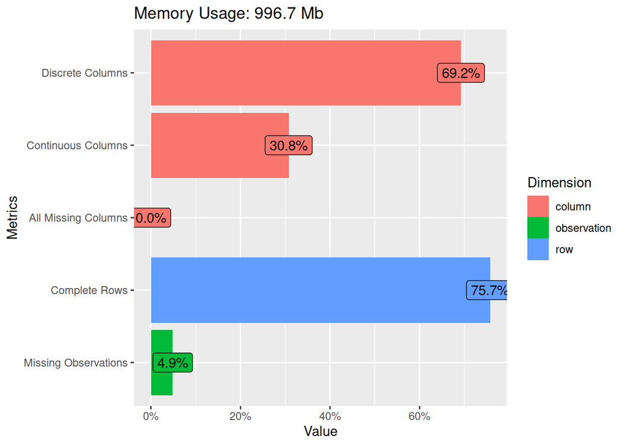

```r
plot_intro(data)
```

It seems we have some missing values, as stated in the table above.  
* 75.7% of the rows are complete. * 4.9% missing observations.

Lets take a closer look at the the missing data

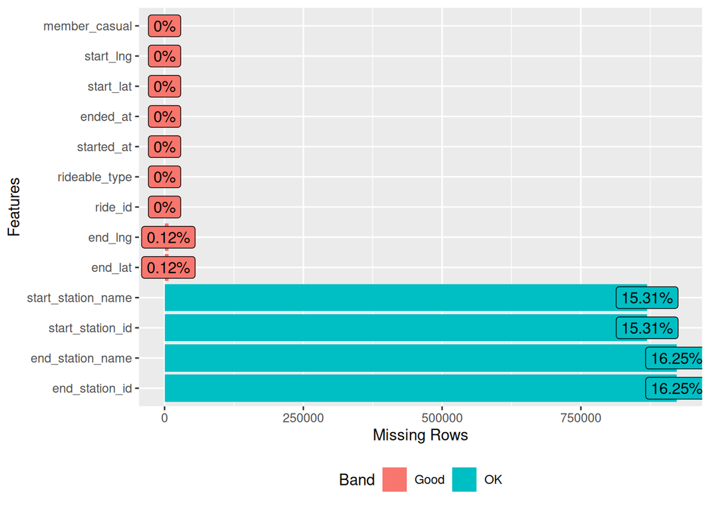

```r
plot_missing(data)
```

Given that we have the most of the start and end latitudes we maybe able to fill these missing values with confidence. Lets find out.

### 6. Data Cleaning

Lets check how many unique station IDs we have compared to unique sets of starting or ending co-ordinates.

```r
# Count unique station ids
unique_station_ids <- data %>%
  select(start_station_id, end_station_id) %>%
  distinct() %>%
  summarise(count = n())

# Count unique start_lat and start_long combinations
unique_start_lat_long <- data %>%
  select(start_lat, start_lng) %>%
  distinct() %>%
  summarise(count = n())

# Count unique end_lat and end_long combinations
unique_end_lat_long <- data %>%
  select(end_lat, end_lng) %>%
  distinct() %>%
  summarise(count = n())

unique_station_ids$count
```

```
## [1] 171871
```

```r
unique_start_lat_long$count
```

```
## [1] 2028793
```

```r
unique_end_lat_long$count
```

```
## [1] 15321
```

By comparing the unique station IDs with the starting and ending lats and longs we can see that there must be some inconsistency in the data so we will not be able to match them. So lets drop them from the table so we have clean data to work with.

```r
data_clean <- drop_na(data)
skim_without_charts(data_clean)
```

Data summary

| Name | data_clean |
| --- | --- |
| Number of rows | 4299967 |
| Number of columns | 13 |
| _______________________ |  |
| Column type frequency: |  |
| character | 7 |
| numeric | 4 |
| POSIXct | 2 |
| ________________________ |  |
| Group variables | None |

**Variable type: character**

| skim_variable | n_missing | complete_rate | min | max | empty | n_unique | whitespace |
| --- | --- | --- | --- | --- | --- | --- | --- |
| ride_id | 0 | 1 | 16 | 16 | 0 | 4299967 | 0 |
| rideable_type | 0 | 1 | 11 | 13 | 0 | 3 | 0 |
| start_station_name | 0 | 1 | 3 | 64 | 0 | 1526 | 0 |
| start_station_id | 0 | 1 | 3 | 35 | 0 | 1455 | 0 |
| end_station_name | 0 | 1 | 3 | 64 | 0 | 1556 | 0 |
| end_station_id | 0 | 1 | 3 | 35 | 0 | 1477 | 0 |
| member_casual | 0 | 1 | 6 | 6 | 0 | 2 | 0 |

**Variable type: numeric**

| skim_variable | n_missing | complete_rate | mean | sd | p0 | p25 | p50 | p75 | p100 |
| --- | --- | --- | --- | --- | --- | --- | --- | --- | --- |
| start_lat | 0 | 1 | 41.90 | 0.04 | 41.65 | 41.88 | 41.90 | 41.93 | 42.06 |
| start_lng | 0 | 1 | -87.64 | 0.02 | -87.84 | -87.66 | -87.64 | -87.63 | -87.53 |
| end_lat | 0 | 1 | 41.90 | 0.06 | 0.00 | 41.88 | 41.90 | 41.93 | 42.06 |
| end_lng | 0 | 1 | -87.64 | 0.08 | -87.84 | -87.66 | -87.64 | -87.63 | 0.00 |

**Variable type: POSIXct**

| skim_variable | n_missing | complete_rate | min | max | median | n_unique |
| --- | --- | --- | --- | --- | --- | --- |
| started_at | 0 | 1 | 2022-12-01 00:01:22 | 2023-11-30 23:58:38 | 2023-07-12 16:52:18 | 3761459 |
| ended_at | 0 | 1 | 2022-12-01 00:03:41 | 2023-12-01 09:47:35 | 2023-07-12 17:04:54 | 3771902 |

We had 5677610 rows of data before dropping th null values, now we have 4299967 We cleaned 1377643 rows of data which is about 25% Lets check for duplicates.

Now we have clean data to work with lets do some data wrangling.

### 7. Data wrangling

We dont need the latitude and longditude columns as the data serves us no purpose so we can remove them.

```r
data_clean <- select(data_clean,-c(start_lat, start_lng, end_lat, end_lng))
head(data_clean)
```

```
## # A tibble: 6 × 9
##   ride_id          rideable_type started_at          ended_at
##   <chr>            <chr>         <dttm>              <dttm>
## 1 65DBD2F447EC51C2 electric_bike 2022-12-05 10:47:18 2022-12-05 10:56:34
## 2 0C201AA7EA0EA1AD classic_bike  2022-12-18 06:42:33 2022-12-18 07:08:44
## 3 E0B148CCB358A49D electric_bike 2022-12-13 08:47:45 2022-12-13 08:59:51
## 4 54C5775D2B7C9188 classic_bike  2022-12-13 18:50:47 2022-12-13 19:19:48
## 5 A4891F78776D35DF classic_bike  2022-12-14 16:13:39 2022-12-14 16:27:50
## 6 DB91D9B8DFACA07A electric_bike 2022-12-02 15:24:47 2022-12-02 15:34:14
## # ℹ 5 more variables: start_station_name <chr>, start_station_id <chr>,
## #   end_station_name <chr>, end_station_id <chr>, member_casual <chr>
```

The column names are unclear so lets rename them

```r
data_clean <- rename(data_clean, trip_id = ride_id,
                     bike_type = rideable_type,
                     start_time = started_at,
                     end_time = ended_at,
                     from_station_name = start_station_name,
                     from_station_id = start_station_id,
                     to_station_name = end_station_name,
                     to_station_id = end_station_id,
                     user_type = member_casual)
head(data_clean)
```

```
## # A tibble: 6 × 9
##   trip_id    bike_type start_time          end_time            from_station_name
##   <chr>      <chr>     <dttm>              <dttm>              <chr>
## 1 65DBD2F44… electric… 2022-12-05 10:47:18 2022-12-05 10:56:34 Clifton Ave & Ar…
## 2 0C201AA7E… classic_… 2022-12-18 06:42:33 2022-12-18 07:08:44 Broadway & Belmo…
## 3 E0B148CCB… electric… 2022-12-13 08:47:45 2022-12-13 08:59:51 Sangamon St & La…
## 4 54C5775D2… classic_… 2022-12-13 18:50:47 2022-12-13 19:19:48 Shields Ave & 31…
## 5 A4891F787… classic_… 2022-12-14 16:13:39 2022-12-14 16:27:50 Ashland Ave & Ch…
## 6 DB91D9B8D… electric… 2022-12-02 15:24:47 2022-12-02 15:34:14 Wabash Ave & 9th…
## # ℹ 4 more variables: from_station_id <chr>, to_station_name <chr>,
## #   to_station_id <chr>, user_type <chr>
```

```r
nrow(data_clean)
```

```
## [1] 4299967
```

We can also remove any duplicated rows from the dataset based on the ride_id

```r
data_clean <- data_clean[!duplicated(data_clean$trip_id),]
nrow(data_clean)
```

```
## [1] 4299967
```

Seems like we got rid of all the bad fruit earlier.

Lets now add some columns for the days for the week and what year month and the hour of the day the ride started.

```r
data_clean <- data_clean %>%
  mutate(year = year(start_time),
         month = month(start_time, label = T),
         wday = wday(start_time, label= T),
         hour = format(as.POSIXct(start_time, format="%Y-%m-%d %H:%M"),format="%H"),
         duration_min = round(as.numeric(difftime(end_time,start_time,
                        units = "mins")),0)) %>%
select(-1)
head(data_clean)
```

```
## # A tibble: 6 × 13
##   bike_type     start_time          end_time            from_station_name
##   <chr>         <dttm>              <dttm>              <chr>
## 1 electric_bike 2022-12-05 10:47:18 2022-12-05 10:56:34 Clifton Ave & Armitage …
## 2 classic_bike  2022-12-18 06:42:33 2022-12-18 07:08:44 Broadway & Belmont Ave
## 3 electric_bike 2022-12-13 08:47:45 2022-12-13 08:59:51 Sangamon St & Lake St
## 4 classic_bike  2022-12-13 18:50:47 2022-12-13 19:19:48 Shields Ave & 31st St
## 5 classic_bike  2022-12-14 16:13:39 2022-12-14 16:27:50 Ashland Ave & Chicago A…
## 6 electric_bike 2022-12-02 15:24:47 2022-12-02 15:34:14 Wabash Ave & 9th St
## # ℹ 9 more variables: from_station_id <chr>, to_station_name <chr>,
## #   to_station_id <chr>, user_type <chr>, year <dbl>, month <ord>, wday <ord>,
## #   hour <chr>, duration_min <dbl>
```

Lets check the min and max ride times to see if we have more odd numbers.

```r
max(data_clean$duration_min)
```

```
## [1] 12136
```

```r
min(data_clean$duration_min)
```

```
## [1] -55
```

We better check for outliers

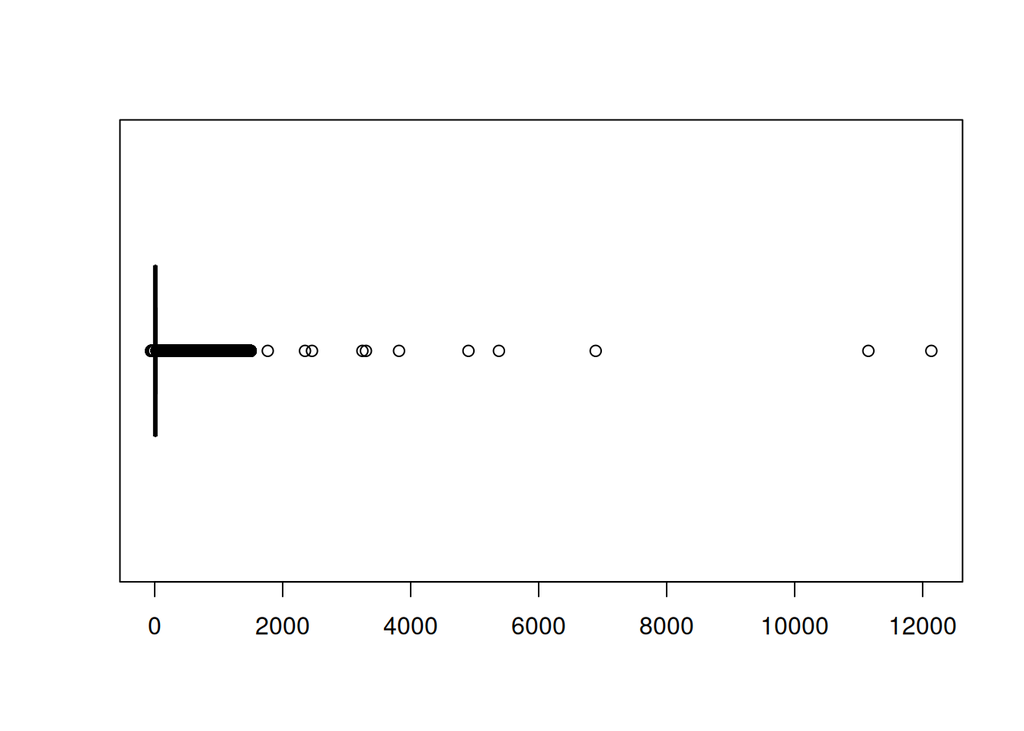

```r
boxplot(data_clean$duration_min, horizontal = TRUE)
```

It seems we have more bad data, there is only 1440 minutes in a day so a rental for 12136 or 8.5 days seems a bit odd, but it could be a user who didn’t return the bike or used it for multiple days. Here some information on pricing would be helpful to learn what policies they have. We also have a negative number of -55 and we cant be sure about if that was inputted incorrectly or a system error so we will remove it and then move on. Given that the business task is to get more causal users to become members we can also take a look at that.

```r
data_clean <- subset(data_clean, duration_min > 0)
min(data_clean$duration_min)
```

```
## [1] 1
```

1 minute bike rides are not acceptable either, they must have been checking the bike so lets use data where the ride was 1 min or greater but from 1 station to another

```r
data_clean <- subset(data_clean,!(from_station_name == to_station_name & duration_min <= 1))
data_clean <- subset(data_clean,duration_min >= 1)
min(data_clean$duration_min)
```

```
## [1] 1
```

Lets add some more columns so we can see the peak usage times

```r
data_clean$starting_time <- as.numeric(format(data_clean$start_time, "%H.%M"))


data_clean <- data_clean %>% mutate(rush_hour = case_when(starting_time >= 6.0 & starting_time <= 08.59 ~ "Morning rush",
                                                          starting_time >= 9.0 & starting_time <= 11.59 ~ "Late morning",
                                                          starting_time >= 12 & starting_time <= 15.59 ~ "Afternoon",
                                                          starting_time >= 16.0 & starting_time <= 18.59 ~ "Evening rush",
                                                          starting_time >= 19.0 & starting_time <= 23.59 ~ "Night" ,
                                                          starting_time >= 0.0 & starting_time <= 5.59  ~ "Midnight hours"))

data_clean <- select(data_clean,-starting_time)

head(data_clean)
```

```
## # A tibble: 6 × 14
##   bike_type     start_time          end_time            from_station_name
##   <chr>         <dttm>              <dttm>              <chr>
## 1 electric_bike 2022-12-05 10:47:18 2022-12-05 10:56:34 Clifton Ave & Armitage …
## 2 classic_bike  2022-12-18 06:42:33 2022-12-18 07:08:44 Broadway & Belmont Ave
## 3 electric_bike 2022-12-13 08:47:45 2022-12-13 08:59:51 Sangamon St & Lake St
## 4 classic_bike  2022-12-13 18:50:47 2022-12-13 19:19:48 Shields Ave & 31st St
## 5 classic_bike  2022-12-14 16:13:39 2022-12-14 16:27:50 Ashland Ave & Chicago A…
## 6 electric_bike 2022-12-02 15:24:47 2022-12-02 15:34:14 Wabash Ave & 9th St
## # ℹ 10 more variables: from_station_id <chr>, to_station_name <chr>,
## #   to_station_id <chr>, user_type <chr>, year <dbl>, month <ord>, wday <ord>,
## #   hour <chr>, duration_min <dbl>, rush_hour <chr>
```

Now we have clean data and some extra columns to work with so we can start the analysis

### 8. Analysis

Lets Calculate the average ride_length for members and casual riders.

```r
data_clean %>%
  group_by(user_type) %>%
  summarise_at(vars(duration_min), list(average_ride_time = mean))
```

```
## # A tibble: 2 × 2
##   user_type average_ride_time
##   <chr>                 <dbl>
## 1 casual                 23.4
## 2 member                 12.4
```

Calculate the average ride_time for users by day_of_week.

```r
data_clean%>%
group_by(user_type, wday) %>%
summarise(n = n(), duration=mean(duration_min))%>%
mutate(percentage = round(n/sum(n) *100))
```

```
## # A tibble: 14 × 5
## # Groups:   user_type [2]
##    user_type wday       n duration percentage
##    <chr>     <ord>  <int>    <dbl>      <dbl>
##  1 casual    Sun   247410     27.2         17
##  2 casual    Mon   171541     23.0         11
##  3 casual    Tue   178026     20.9         12
##  4 casual    Wed   178166     20.0         12
##  5 casual    Thu   195172     20.4         13
##  6 casual    Fri   221388     22.8         15
##  7 casual    Sat   301647     26.5         20
##  8 member    Sun   295656     14.0         11
##  9 member    Mon   375510     11.8         14
## 10 member    Tue   438135     11.9         16
## 11 member    Wed   436796     11.9         16
## 12 member    Thu   440985     11.8         16
## 13 member    Fri   383814     12.3         14
## 14 member    Sat   336639     14.0         12
```

Ride count by user, month

```r
month <- data_clean %>%
    group_by(user_type, month) %>%
    summarise(numberofrides = n(),.groups = "drop")

month
```

```
## # A tibble: 24 × 3
##    user_type month numberofrides
##    <chr>     <ord>         <int>
##  1 casual    Jan           28904
##  2 casual    Feb           32031
##  3 casual    Mar           45563
##  4 casual    Apr          107690
##  5 casual    May          172850
##  6 casual    Jun          214864
##  7 casual    Jul          239716
##  8 casual    Aug          229093
##  9 casual    Sep          193149
## 10 casual    Oct          127792
## # ℹ 14 more rows
```

lets check the user types and see the customer base

```r
data_clean %>%
  count(user_type) %>%
  mutate(percent = n/nrow(data_clean),
         "%" = paste0(round(percent * 100)))
```

```
## # A tibble: 2 × 4
##   user_type       n percent `%`
##   <chr>       <int>   <dbl> <chr>
## 1 casual    1493350   0.355 36
## 2 member    2707535   0.645 64
```

Lets see how the rides break down by bike type

```r
data_clean %>%
  count(bike_type) %>%
  mutate(percent = n/nrow(data_clean),
         "%" = paste0(round(percent*100)))
```

```
## # A tibble: 3 × 4
##   bike_type           n percent `%`
##   <chr>           <int>   <dbl> <chr>
## 1 classic_bike  2613524  0.622  62
## 2 docked_bike     77074  0.0183 2
## 3 electric_bike 1510287  0.360  36
```

```r
data_clean %>%
  group_by(bike_type) %>%
  summarise(total=n()) %>% #
  mutate(total_hours = round(total/60),
         days = round(total_hours/24))
```

```
## # A tibble: 3 × 4
##   bike_type       total total_hours  days
##   <chr>           <int>       <dbl> <dbl>
## 1 classic_bike  2613524       43559  1815
## 2 docked_bike     77074        1285    54
## 3 electric_bike 1510287       25171  1049
```

Lets get the top 10 pickup points for each day of the week.

```r
data_clean %>%
  group_by(user_type, wday,from_station_name) %>%
  summarise(total=n(),duration=mean(duration_min)) %>%
  arrange(desc(total))%>%
  slice_head(n=10)
```

```
## # A tibble: 140 × 5
## # Groups:   user_type, wday [14]
##    user_type wday  from_station_name                  total duration
##    <chr>     <ord> <chr>                              <int>    <dbl>
##  1 casual    Sun   Streeter Dr & Grand Ave             8057     37.0
##  2 casual    Sun   DuSable Lake Shore Dr & Monroe St   5535     37.9
##  3 casual    Sun   Michigan Ave & Oak St               4219     38.0
##  4 casual    Sun   Millennium Park                     3762     41.8
##  5 casual    Sun   DuSable Lake Shore Dr & North Blvd  3688     29.7
##  6 casual    Sun   Theater on the Lake                 3252     31.2
##  7 casual    Sun   Shedd Aquarium                      3095     30.3
##  8 casual    Sun   Dusable Harbor                      2872     37.5
##  9 casual    Sun   Montrose Harbor                     2248     35.8
## 10 casual    Sun   Adler Planetarium                   2131     34.2
## # ℹ 130 more rows
```

```r
# Rides by user, hour
hour <- data_clean %>%
    group_by(user_type, hour) %>%
    summarise(numberofrides = n(),.groups = 'drop') %>%
      arrange(hour)

hour
```

```
## # A tibble: 48 × 3
##    user_type hour  numberofrides
##    <chr>     <chr>         <int>
##  1 casual    00            24258
##  2 member    00            22715
##  3 casual    01            15587
##  4 member    01            13132
##  5 casual    02             9012
##  6 member    02             7206
##  7 casual    03             4574
##  8 member    03             4600
##  9 casual    04             3552
## 10 member    04             5803
## # ℹ 38 more rows
```

number of rides by user and period of the day

```r
rushhour <- data_clean %>%
    group_by(user_type, rush_hour) %>%
    summarise(numberofrides = n(),.groups = 'drop')  %>%
      arrange(rush_hour)
rushhour
```

```
## # A tibble: 12 × 3
##    user_type rush_hour      numberofrides
##    <chr>     <chr>                  <int>
##  1 casual    Afternoon             420754
##  2 member    Afternoon             621205
##  3 casual    Evening rush          405827
##  4 member    Evening rush          771809
##  5 casual    Late morning          200058
##  6 member    Late morning          361590
##  7 casual    Midnight hours         65007
##  8 member    Midnight hours         79388
##  9 casual    Morning rush          112152
## 10 member    Morning rush          425451
## 11 casual    Night                 289552
## 12 member    Night                 448092
```

lets have a look at the users and the longer rides or multi day hires

```r
long_hire <- data_clean %>%
  group_by(user_type) %>%
  mutate(longhire = case_when(duration_min >= 1 & duration_min <= 20 ~ "0 - 20 min",
                               duration_min >= 21 & duration_min <= 60 ~ "20-60 min",
                               duration_min >= 61 & duration_min <= 120 ~ "1-2 hrs",
                               duration_min >= 121 & duration_min <= 240 ~ "2-4 hrs",
                               duration_min >= 241 & duration_min <= 480 ~ "4-8 hrs" ,
                               duration_min >= 481 & duration_min <= 1440 ~ "8-24hrs",
                               duration_min >= 1441 & duration_min <= 2880 ~ "1-2 days",
                               duration_min >= 2881 & duration_min <= 5760 ~ "2-4 days",
                               duration_min >= 5760 ~ "5 days or more")) %>%
  group_by( longhire, user_type, wday) %>%
  summarise(numberofrides = n(),.groups = 'drop') %>%
  mutate(longhire = factor(longhire, levels = c("0 - 20 min", "20-60 min", "1-2 hrs", "2-4 hrs", "4-8 hrs", "8-24hrs", "1-2 days", "2-4 days", "5 days or more")))

long_hire
```

```
## # A tibble: 105 × 4
##    longhire   user_type wday  numberofrides
##    <fct>      <chr>     <ord>         <int>
##  1 0 - 20 min casual    Sun          153099
##  2 0 - 20 min casual    Mon          119973
##  3 0 - 20 min casual    Tue          131159
##  4 0 - 20 min casual    Wed          134837
##  5 0 - 20 min casual    Thu          146341
##  6 0 - 20 min casual    Fri          154978
##  7 0 - 20 min casual    Sat          188551
##  8 0 - 20 min member    Sun          241550
##  9 0 - 20 min member    Mon          327417
## 10 0 - 20 min member    Tue          381070
## # ℹ 95 more rows
```

Lets clean up the results and find out the percentages for the causal users

```r
data_clean_casual <- data_clean %>% filter(user_type == "casual")


long_hire1 <- data_clean_casual %>%
  group_by(user_type) %>%
  mutate(longhire = cut(duration_min,
                        breaks = c(0, 20, 60, 120, 240, 480, 1440, 2880, 5760, Inf),
                        labels = c("0 - 20 min", "20-60 min", "1-2 hrs", "2-4 hrs", "4-8 hrs", "8-24hrs", "1-2 days", "2-4 days", "5 days or more"))) %>%
  group_by(longhire, user_type) %>%
  summarise(numberofrides = n(), .groups = 'drop') %>%
  mutate(longhire = fct_relevel(factor(longhire), "0 - 20 min", "20-60 min", "1-2 hrs", "2-4 hrs", "4-8 hrs", "8-24hrs", "1-2 days", "2-4 days", "5 days or more"),
         total_rides = sum(numberofrides),
         percentage = round(numberofrides / total_rides * 100, 2))

long_hire1
```

```
## # A tibble: 9 × 5
##   longhire       user_type numberofrides total_rides percentage
##   <fct>          <chr>             <int>       <int>      <dbl>
## 1 0 - 20 min     casual          1028938     1493350      68.9
## 2 20-60 min      casual           366429     1493350      24.5
## 3 1-2 hrs        casual            73686     1493350       4.93
## 4 2-4 hrs        casual            18596     1493350       1.25
## 5 4-8 hrs        casual             2740     1493350       0.18
## 6 8-24hrs        casual             2856     1493350       0.19
## 7 1-2 days       casual               97     1493350       0.01
## 8 2-4 days       casual                5     1493350       0
## 9 5 days or more casual                3     1493350       0
```

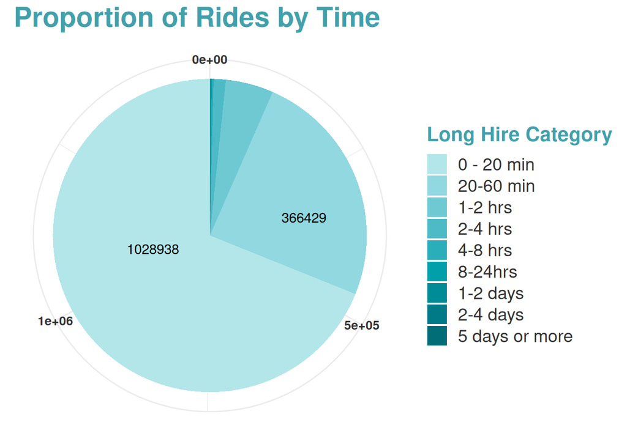

```r
library(ggrepel)

ggplot(long_hire1, aes(x = "", y = numberofrides, fill = longhire)) +
  geom_bar(stat = "identity", width = 1) +
  coord_polar("y", start = 0) +
  labs(title = "Proportion of Rides by Time",
       x = NULL,
       y = NULL,
       fill = "Long Hire Category") +
  theme_minimal() +
  scale_fill_manual(values = c("#b3e6e9","#91d8e0", "#6fc9d3", "#4dbac6", "#2aaeb9", "#009faa", "#008c97" , "#007a87", "#006d77" )) +
  geom_text_repel(aes(label=numberofrides), box.padding=0.5, point.padding=0.5) +
   theme(plot.title = element_text(size = 22, color = "#42a0ab", face = "bold"),
    plot.subtitle = element_text(size = 14, color = "grey20", face = "bold"),
    plot.caption = element_text(size = 8, color = "grey35"),
    legend.title = element_text(size = 16, face = "bold", color = "#42a0ab"),
    legend.text = element_text(size = 14, color = "grey20"),
    axis.title.x = element_text(size = 15, color = "#42a0ab", face = "bold"),
    axis.title.y = element_text(size = 15, color = "#42a0ab", face = "bold"),
    axis.text.x = element_text(size = 10, color = "grey20", face = "bold"),
    axis.text.y = element_text(size = 10, color = "grey20", face = "bold"))
```

### 9. Visual Analysis

Lets plot the different user types

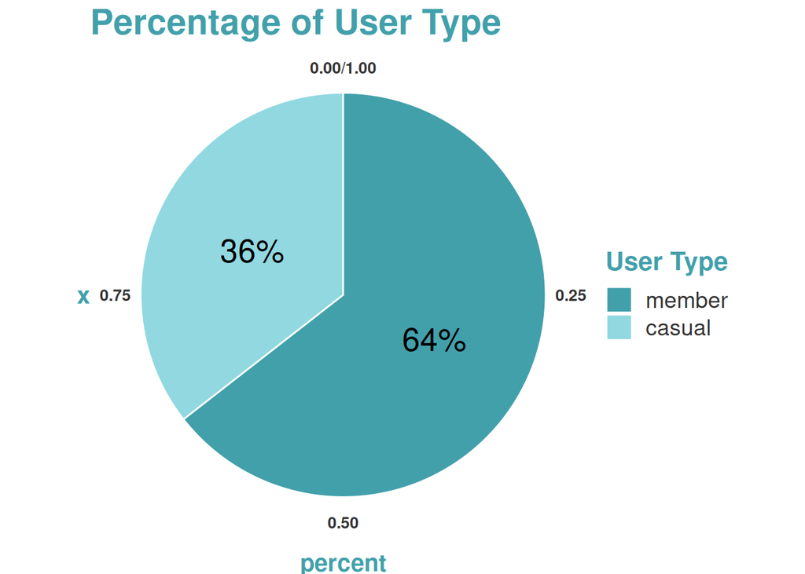

```r
data_clean %>%
  count(user_type) %>%
  mutate(percent = n/nrow(data_clean),
         percent_label = paste0(round(percent * 100), "%")) %>%
  ggplot(aes("", percent, fill = user_type, label = percent_label)) +
  geom_col(color = "white") +
  geom_text(color = "black",
            position = position_stack(vjust = 0.5),
            size = 7) +
  coord_polar(theta = "y", start = 0) +
  theme_void() +
  guides(fill = guide_legend(reverse = TRUE)) +
  scale_fill_manual(values = c("#91d8e0","#42a0ab")) +
  labs(fill = "User Type" ,
       title = "Percentage of User Type") +
  theme(plot.title = element_text(size = 22, color = "#42a0ab", face = "bold"),
    plot.subtitle = element_text(size = 14, color = "grey20", face = "bold"),
    plot.caption = element_text(size = 8, color = "grey35"),
    legend.title = element_text(size = 16, face = "bold", color = "#42a0ab"),
    legend.text = element_text(size = 14, color = "grey20"),
    axis.title.x = element_text(size = 15, color = "#42a0ab", face = "bold"),
    axis.title.y = element_text(size = 15, color = "#42a0ab", face = "bold"),
    axis.text.x = element_text(size = 10, color = "grey20", face = "bold"),
    axis.text.y = element_text(size = 10, color = "grey20", face = "bold"))
```

Lets now have a look at what type of bikes each user type used.

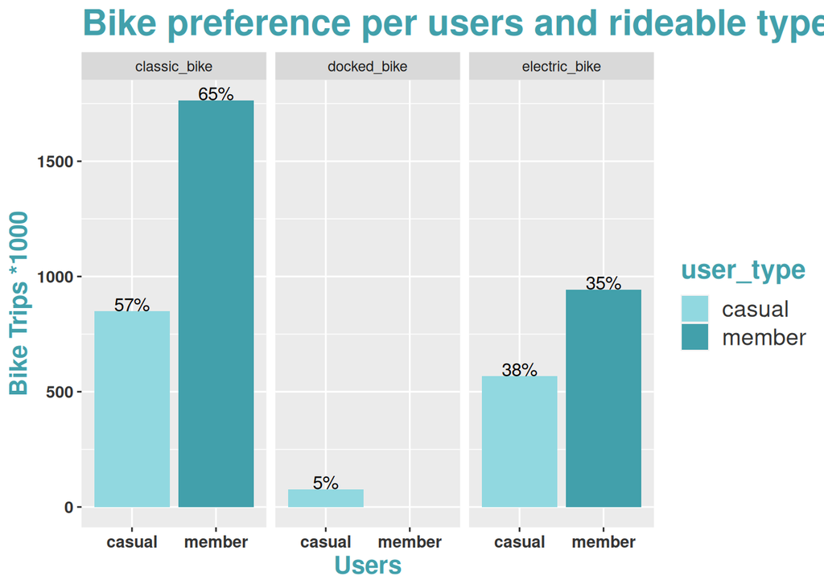

```r
ggplot(
     data_clean%>%
    group_by(user_type, bike_type) %>%
    summarise(n = n())%>%
    mutate(percentage = n/sum(n) *100) ,
    aes(x=user_type, y=n/1000, fill=user_type)
) +
geom_col(position="dodge") +
scale_fill_manual(values = c("#91d8e0","#42a0ab")) +
geom_text(aes(label = paste0(round(percentage), "%")), position=position_dodge(0.85), vjust = 0) +
labs(x="Users", y="Bike Trips *1000", title="Bike preference per users and rideable type")+
  theme(plot.title = element_text(size = 22, color = "#42a0ab", face = "bold"),
    plot.subtitle = element_text(size = 14, color = "grey20", face = "bold"),
    plot.caption = element_text(size = 8, color = "grey35"),
    legend.title = element_text(size = 16, face = "bold", color = "#42a0ab"),
    legend.text = element_text(size = 14, color = "grey20"),
    axis.title.x = element_text(size = 15, color = "#42a0ab", face = "bold"),
    axis.title.y = element_text(size = 15, color = "#42a0ab", face = "bold"),
    axis.text.x = element_text(size = 10, color = "grey20", face = "bold"),
    axis.text.y = element_text(size = 10, color = "grey20", face = "bold"))+
facet_wrap(~bike_type)
```

[figure not shown]

Lets look at when the most rides occur.

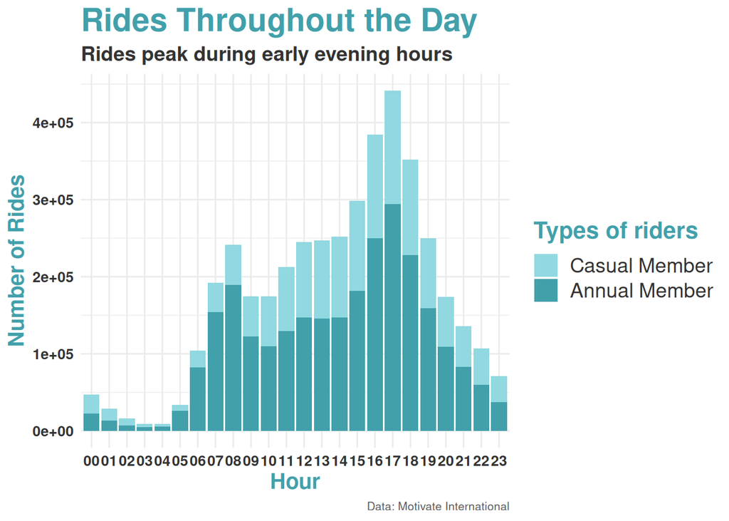

```r
ggplot(hour, aes(hour, numberofrides,  fill = user_type, group = user_type)) +
geom_bar(stat = "identity") +
scale_fill_manual(values = c("#91d8e0", "#42a0ab"), name = "Types of riders", breaks = c("casual", "member"), labels = c("Casual Member", "Annual Member")) +
labs(title = "Rides Throughout the Day", subtitle = "Rides peak during early evening hours",
    caption = "Data: Motivate International",
    x = "Hour", y = "Number of Rides") +
theme_minimal() +
theme(plot.title = element_text(size = 22, color = "#42a0ab", face = "bold"),
    plot.subtitle = element_text(size = 14, color = "grey20", face = "bold"),
    plot.caption = element_text(size = 8, color = "grey35"),
    legend.title = element_text(size = 16, face = "bold", color = "#42a0ab"),
    legend.text = element_text(size = 14, color = "grey20"),
    axis.title.x = element_text(size = 15, color = "#42a0ab", face = "bold"),
    axis.title.y = element_text(size = 15, color = "#42a0ab", face = "bold"),
    axis.text.x = element_text(size = 10, color = "grey20", face = "bold"),
    axis.text.y = element_text(size = 10, color = "grey20", face = "bold"))
```

Lets break this down further into peak times such as morning and evening traditional work times.

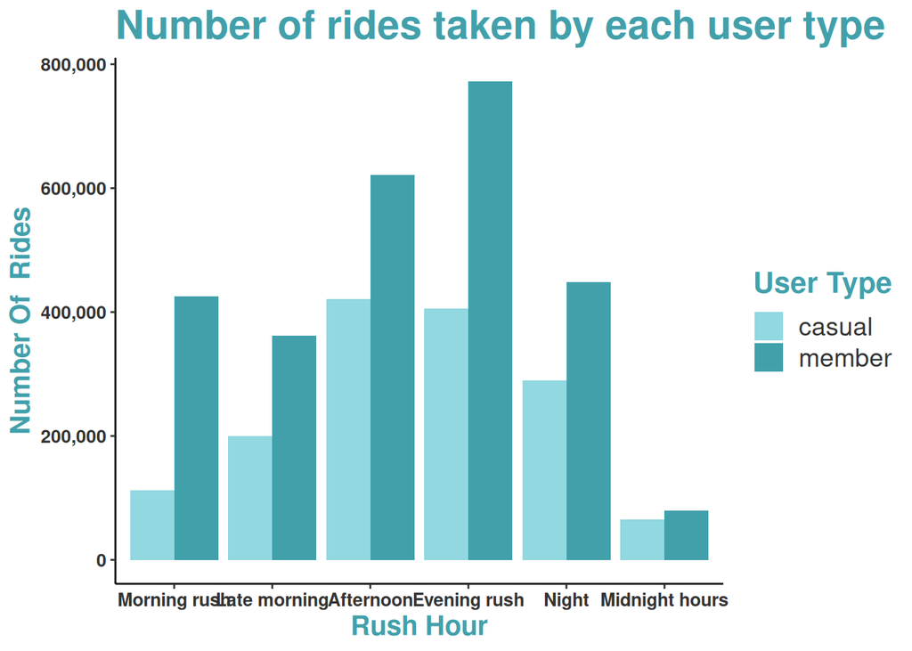

```r
rushhour %>% ggplot(mapping = aes(x=rush_hour, y= numberofrides, fill = user_type)) +
  geom_col(position="dodge") +
  scale_x_discrete(limits = c("Morning rush", "Late morning", "Afternoon", "Evening rush", "Night", "Midnight hours")) +
  scale_y_continuous(labels = comma) +
  scale_fill_manual(values = c("#91d8e0", "#42a0ab")) +
  ggtitle("Number of rides taken by each user type") +
  xlab("Rush Hour") +
  ylab("Number Of  Rides") +
  labs(fill = "User Type")+
  theme_classic()+
  theme(plot.title = element_text(size = 22, color = "#42a0ab", face = "bold"),
    plot.subtitle = element_text(size = 14, color = "grey20", face = "bold"),
    plot.caption = element_text(size = 8, color = "grey35"),
    legend.title = element_text(size = 16, face = "bold", color = "#42a0ab"),
    legend.text = element_text(size = 14, color = "grey20"),
    axis.title.x = element_text(size = 15, color = "#42a0ab", face = "bold"),
    axis.title.y = element_text(size = 15, color = "#42a0ab", face = "bold"),
    axis.text.x = element_text(size = 10, color = "grey20", face = "bold"),
    axis.text.y = element_text(size = 10, color = "grey20", face = "bold"))
```

Lets have a closer look at the multi-day hires. Lets drop the rides of an hour or less because they make up the vast majority.

```r
long_hire_filtered <- long_hire %>%
  filter(longhire != "0 - 20 min" & longhire != "20-60 min")
```

```r
grouped_hire_duration_plot <- ggplot(long_hire_filtered, aes(x = user_type, y = numberofrides, fill = longhire)) +
  geom_bar(stat = "identity", position = "dodge") +
  labs(title = "Rental length by user type",
       x = "User Type",
       y = "Number of Rides",
       fill = "Rental time") +
  theme_minimal() +
  scale_fill_manual(values = c("#b3e6e9","#91d8e0", "#6fc9d3", "#4dbac6", "#2aaeb9", "#009faa", "#008c97"  )) +
  scale_y_log10() +
  theme(plot.title = element_text(size = 22, color = "#42a0ab", face = "bold"),
    plot.subtitle = element_text(size = 14, color = "grey20", face = "bold"),
    plot.caption = element_text(size = 8, color = "grey35"),
    legend.title = element_text(size = 16, face = "bold", color = "#42a0ab"),
    legend.text = element_text(size = 14, color = "grey20"),
    axis.title.x = element_text(size = 15, color = "#42a0ab", face = "bold"),
    axis.title.y = element_text(size = 15, color = "#42a0ab", face = "bold"),
    axis.text.x = element_text(size = 10, color = "grey20", face = "bold"),
    axis.text.y = element_text(size = 10, color = "grey20", face = "bold"))
```

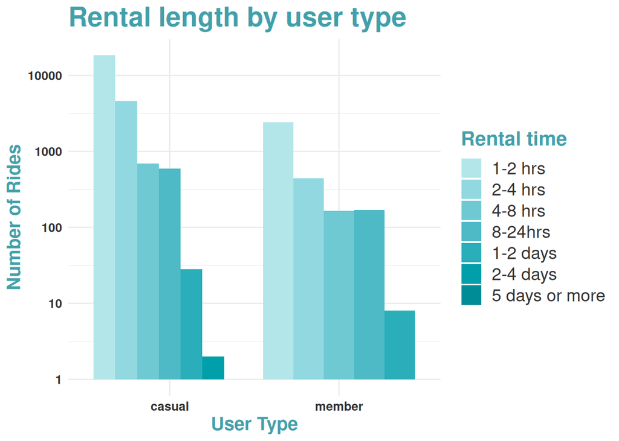

```r
grouped_hire_duration_plot
```

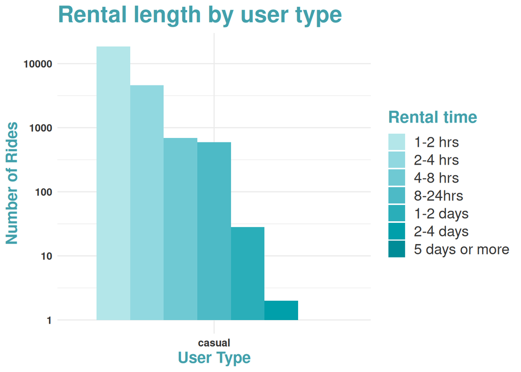

```r
casual_filtered <- long_hire_filtered %>%  filter(user_type != 'member')

ggplot(casual_filtered, aes(x = user_type, y = numberofrides, fill = longhire)) +
  geom_bar(stat = "identity", position = "dodge") +
  labs(title = "Rental length by user type",
       x = "User Type",
       y = "Number of Rides",
       fill = "Rental time") +
  theme_minimal() +
  scale_fill_manual(values = c("#b3e6e9","#91d8e0", "#6fc9d3", "#4dbac6", "#2aaeb9", "#009faa", "#008c97"  )) +
  scale_y_log10() +
  #geom_text(aes(label = numberofrides), position = position_dodge(width = 0.9), vjust = -0.5)+
  theme(plot.title = element_text(size = 22, color = "#42a0ab", face = "bold"),
    plot.subtitle = element_text(size = 14, color = "grey20", face = "bold"),
    plot.caption = element_text(size = 8, color = "grey35"),
    legend.title = element_text(size = 16, face = "bold", color = "#42a0ab"),
    legend.text = element_text(size = 14, color = "grey20"),
    axis.title.x = element_text(size = 15, color = "#42a0ab", face = "bold"),
    axis.title.y = element_text(size = 15, color = "#42a0ab", face = "bold"),
    axis.text.x = element_text(size = 10, color = "grey20", face = "bold"),
    axis.text.y = element_text(size = 10, color = "grey20", face = "bold"))
```

Now lets focus in on the rides that lasted longer than a day.

```r
long_hire_filtered1 <- long_hire %>%
  filter(longhire %in% c("1-2 days", "2-4 days", "5 days or more"))

day_or_longer_plot <- ggplot(long_hire_filtered1, aes(x = user_type, y = numberofrides, fill = longhire)) +
  geom_bar(stat = "identity", position = "dodge") +
  labs(title = "Long hire bike rental by user type",
       x = "User Type",
       y = "Number of Rides",
       fill = "Long Hire") +
  theme_minimal() +
  scale_fill_manual(values = c("#b3e6e9","#91d8e0", "#42a0ab")) +
  theme(plot.title = element_text(size = 22, color = "#42a0ab", face = "bold"),
    plot.subtitle = element_text(size = 14, color = "grey20", face = "bold"),
    plot.caption = element_text(size = 8, color = "grey35"),
    legend.title = element_text(size = 16, face = "bold", color = "#42a0ab"),
    legend.text = element_text(size = 14, color = "grey20"),
    axis.title.x = element_text(size = 15, color = "#42a0ab", face = "bold"),
    axis.title.y = element_text(size = 15, color = "#42a0ab", face = "bold"),
    axis.text.x = element_text(size = 10, color = "grey20", face = "bold"),
    axis.text.y = element_text(size = 10, color = "grey20", face = "bold"))
  #geom_text(aes(label = numberofrides), position = position_dodge(width = 0.9), vjust = -0.5)
```

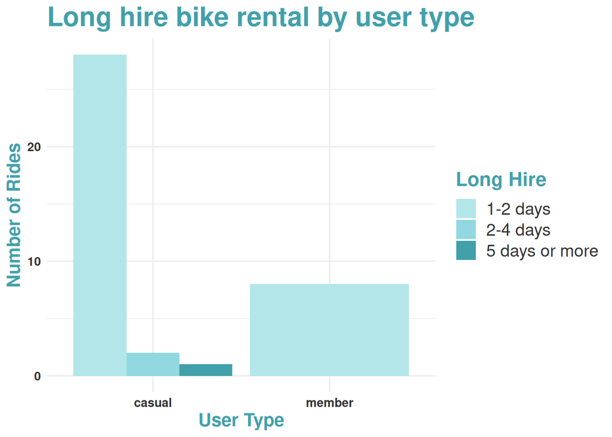

```r
day_or_longer_plot
```

lets see if the day of the week matters

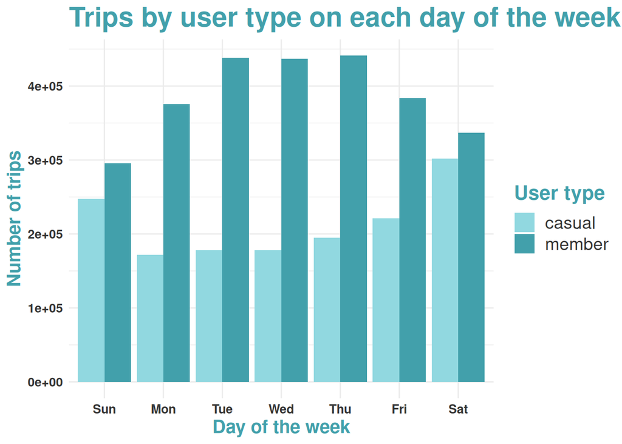

```r
ggplot(data_clean, aes(x = wday, fill = user_type)) +
  geom_bar(position = "dodge") +
  labs(title = "Trips by user type on each day of the week",
       x = "Day of the week",
       y = "Number of trips",
       fill = "User type") +
  theme_minimal() +
    scale_fill_manual(values = c("#91d8e0", "#42a0ab")) +
  theme(plot.title = element_text(size = 22, color = "#42a0ab", face = "bold"),
    plot.subtitle = element_text(size = 14, color = "grey20", face = "bold"),
    plot.caption = element_text(size = 8, color = "grey35"),
    legend.title = element_text(size = 16, face = "bold", color = "#42a0ab"),
    legend.text = element_text(size = 14, color = "grey20"),
    axis.title.x = element_text(size = 15, color = "#42a0ab", face = "bold"),
    axis.title.y = element_text(size = 15, color = "#42a0ab", face = "bold"),
    axis.text.x = element_text(size = 10, color = "grey20", face = "bold"),
    axis.text.y = element_text(size = 10, color = "grey20", face = "bold"))
```

Here we see that Members use the bikes more during the standard working week, and we can see that there is an increase in casual users in the weekend. We can see consistent usage by casual users during the week with an increase towards and during the weekend

Lets have a look at our commuters who use the bikes for less than an hour each day.

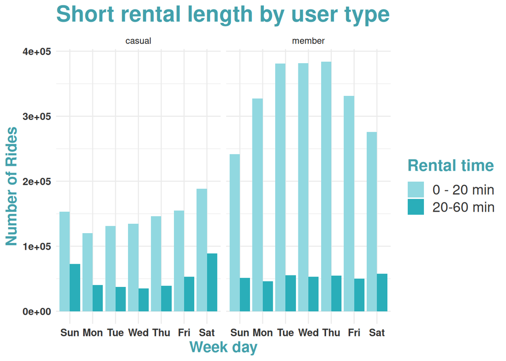

```r
short_hire_filtered <- long_hire %>%
  filter(longhire == "0 - 20 min" | longhire == "20-60 min")

ggplot(short_hire_filtered, aes(x = wday, y = numberofrides, fill = longhire)) +
  geom_bar(stat = "identity", position = "dodge") +
  labs(title = "Short rental length by user type",
       x = "Week day",
       y = "Number of Rides",
       fill = "Rental time") +
  theme_minimal() +
  scale_fill_manual(values = c("#91d8e0", "#2aaeb9"  )) +
    theme(plot.title = element_text(size = 22, color = "#42a0ab", face = "bold"),
    plot.subtitle = element_text(size = 14, color = "grey20", face = "bold"),
    plot.caption = element_text(size = 8, color = "grey35"),
    legend.title = element_text(size = 16, face = "bold", color = "#42a0ab"),
    legend.text = element_text(size = 14, color = "grey20"),
    axis.title.x = element_text(size = 15, color = "#42a0ab", face = "bold"),
    axis.title.y = element_text(size = 15, color = "#42a0ab", face = "bold"),
    axis.text.x = element_text(size = 10, color = "grey20", face = "bold"),
    axis.text.y = element_text(size = 10, color = "grey20", face = "bold"))+
  facet_wrap(~user_type)
```

We can see that more members use the bikes for short commutes during the weekdays, where as more causal users use the bikes for short trips in the weekend.

Lets have a deeper look at the causal users and how the rises stack up on each day of the week.

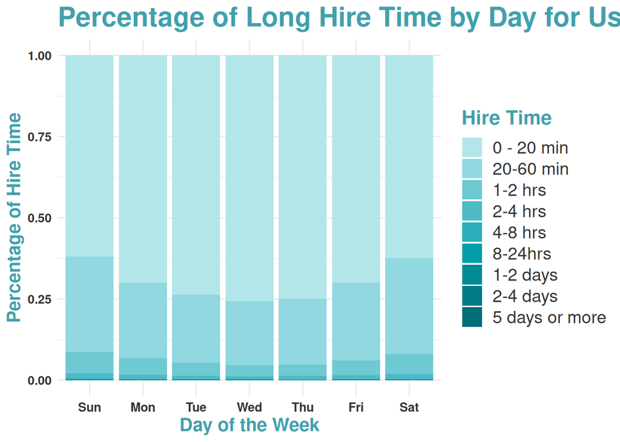

```r
long_hire_wday <- data_clean_casual %>%
  group_by(user_type, wday) %>%
  mutate(longhire = cut(duration_min,
                        breaks = c(0, 20, 60, 120, 240, 480, 1440, 2880, 5760, Inf),
                        labels = c("0 - 20 min", "20-60 min", "1-2 hrs", "2-4 hrs", "4-8 hrs", "8-24hrs", "1-2 days", "2-4 days", "5 days or more"))) %>%
  group_by(longhire, user_type, wday) %>%
  summarise(numberofrides = n(), .groups = 'drop') %>%
  mutate(longhire = fct_relevel(factor(longhire), "0 - 20 min", "20-60 min", "1-2 hrs", "2-4 hrs", "4-8 hrs", "8-24hrs", "1-2 days", "2-4 days", "5 days or more"),
         total_rides = sum(numberofrides),
         percentage = round(numberofrides / total_rides * 100, 2))


# Create a stacked bar chart with the percentage of longhire time for each day
ggplot(long_hire_wday, aes(x = wday, y = percentage, fill = longhire)) +
  geom_bar(stat = "identity", position = "fill") +
  labs(title = "Percentage of Long Hire Time by Day for User Type Casual",
       x = "Day of the Week",
       y = "Percentage of Hire Time",
       fill = "Hire Time") +
  theme_minimal() +
  scale_fill_manual(values = c("#b3e6e9","#91d8e0", "#6fc9d3", "#4dbac6", "#2aaeb9", "#009faa", "#008c97" , "#007a87", "#006d77"    )) +
  theme(plot.title = element_text(size = 22, color = "#42a0ab", face = "bold"),
    plot.subtitle = element_text(size = 14, color = "grey20", face = "bold"),
    plot.caption = element_text(size = 8, color = "grey35"),
    legend.title = element_text(size = 16, face = "bold", color = "#42a0ab"),
    legend.text = element_text(size = 14, color = "grey20"),
    axis.title.x = element_text(size = 15, color = "#42a0ab", face = "bold"),
    axis.title.y = element_text(size = 15, color = "#42a0ab", face = "bold"),
    axis.text.x = element_text(size = 10, color = "grey20", face = "bold"),
    axis.text.y = element_text(size = 10, color = "grey20", face = "bold"))
```

Here we can see that as a percentage, the is a higher use for short 0-20 min trips by casual users during weekdays. Although there are more causal users in the weekend, the week day users seem to mimic those of members.

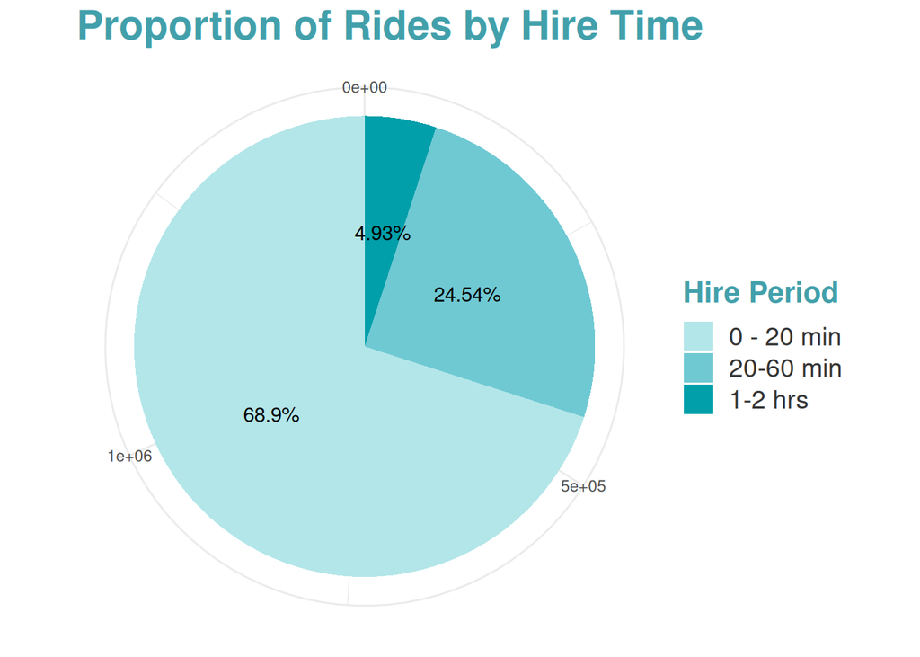

```r
library(ggplot2)

# Filter rows where percentage is greater than 2
long_hire1_filtered <- long_hire1 %>% filter(percentage > 2)

# Create pie chart with filtered data
ggplot(long_hire1_filtered, aes(x = "", y = numberofrides, fill = longhire)) +
  geom_bar(stat = "identity", width = 1) +
  coord_polar(theta = "y", start = 0 ) +
  geom_text(aes(label = ifelse(percentage > 2, paste0(round(percentage, 2), "%"), "")),
            position = position_stack(vjust = 0.5)) +
  labs(title = "Proportion of Rides by Hire Time",
       x = NULL,
       y = NULL,
       fill = "Hire Period") +
  theme_minimal() +
  scale_fill_manual(values = c("#b3e6e9","#6fc9d3", "#009faa",  "#006d77" )) +
    theme(plot.title = element_text(size = 22, color = "#42a0ab", face = "bold"),
    plot.subtitle = element_text(size = 14, color = "grey20", face = "bold"),
    plot.caption = element_text(size = 8, color = "grey35"),
    legend.title = element_text(size = 16, face = "bold", color = "#42a0ab"),
    legend.text = element_text(size = 14, color = "grey20"))
```

Here we confirm that almost 70% of all casual users are using the bikes for short commutes.